# ME613 - Análise de Regressão

## Região de Confiança

## Propriedades

\[\hat{\boldsymbol{\beta}}_{p\times1}\sim \mathcal{N}_p(\boldsymbol{\beta},(\mathbf{X}^T\mathbf{X})^{-1}\sigma^2)\]

\[\frac{1}{\sigma}(\mathbf{X}^T\mathbf{X})^{1/2}(\boldsymbol{\beta}-\hat{\boldsymbol{\beta}})\sim \mathcal{N}_p(\mathbf{0},\mathbf{I}) \]

\[\frac{1}{\sigma^2}(\boldsymbol{\beta}-\hat{\boldsymbol{\beta}})^T(\mathbf{X}^T\mathbf{X})(\boldsymbol{\beta}-\hat{\boldsymbol{\beta}})\sim \chi^2(p)\]

\[(n-p)\frac{s^2}{\sigma^2}\sim\chi^2(n-p)\]

Portanto:

\[\frac{1}{p s^2}(\boldsymbol{\beta}-\hat{\boldsymbol{\beta}})^T\mathbf{X}^T\mathbf{X}(\boldsymbol{\beta}-\hat{\boldsymbol{\beta}})\sim F(p,n-p)\]

## Intervalo de Confiança para \(\beta_k\)

Um intervalo de \(100(1-\alpha)\%\) de confiança para \(\beta_k\) é dado por:

\[\begin{eqnarray} IC(\beta_k, 1-\alpha) &=& \left[\hat{\beta}_k -t_{n-p,\alpha/2}\sqrt{\widehat{Var(\hat{\beta}_k)}};\right.\\ & &\left. \hat{\beta}_k +t_{n-p,\alpha/2}\sqrt{\widehat{Var(\hat{\beta}_k)}}\right] \end{eqnarray}\]

## Exemplo

Estudo sobre diversidade das espécies em Galápagos.

Conjunto de dados: 30 ilhas, 7 variáveis.

`Species`: the number of plant species found on the island

`Endemics`: the number of endemic species

`Area`: the area of the island (km\(^2\))

`Elevation`: the highest elevation of the island (m)

`Nearest`: the distance from the nearest island (km)

`Scruz`: the distance from Santa Cruz island (km)

`Adjacent`: the area of the adjacent island (square km)

## Exemplo

```r
library(faraway)
lmod <- lm(Species ~ Area + Elevation + Nearest + Scruz + Adjacent, gala)
sumary(lmod)
```

```
##              Estimate Std. Error t value  Pr(>|t|)
## (Intercept)  7.068221  19.154198  0.3690 0.7153508
## Area        -0.023938   0.022422 -1.0676 0.2963180
## Elevation    0.319465   0.053663  5.9532 3.823e-06
## Nearest      0.009144   1.054136  0.0087 0.9931506
## Scruz       -0.240524   0.215402 -1.1166 0.2752082
## Adjacent    -0.074805   0.017700 -4.2262 0.0002971
##
## n = 30, p = 6, Residual SE = 60.97519, R-Squared = 0.77
```

## Exemplo

IC 95% para \(\beta_{Adjacent}\):

```r
confint(lmod)[6,]
```

```
##       2.5 %      97.5 %
## -0.11133622 -0.03827344
```

## Região de Confiança para \(\boldsymbol{\beta}\)

Região de Confiança de \(100\times(1-\alpha)\%\): \[\frac{1}{p s^2}(\boldsymbol{\beta}-\hat{\boldsymbol{\beta}})^T\mathbf{X}^T\mathbf{X}(\boldsymbol{\beta}-\hat{\boldsymbol{\beta}})\leq F(p,n-p;1-\alpha)\]

## Exemplo

RC 95% para \(\beta_{Adjacent}\) e \(\beta_{Area}\)

```r
library(ellipse)
aa <- ellipse(lmod,which=c(2,6),level=0.95)
plot(aa,type="l",ylim=c(-0.13,0),col="blue")
points(coef(lmod)[2], coef(lmod)[6], pch=19)
abline(v=confint(lmod)[2,],lty=2)
abline(h=confint(lmod)[6,],lty=2)
abline(h=c(max(aa[,2]),min(aa[,2])),lty=2,col="blue")
abline(v=c(max(aa[,1]),min(aa[,1])),lty=2,col="blue")
```

## Exemplo

RC 95% para \(\beta_{Adjacent}\) e \(\beta_{Area}\)

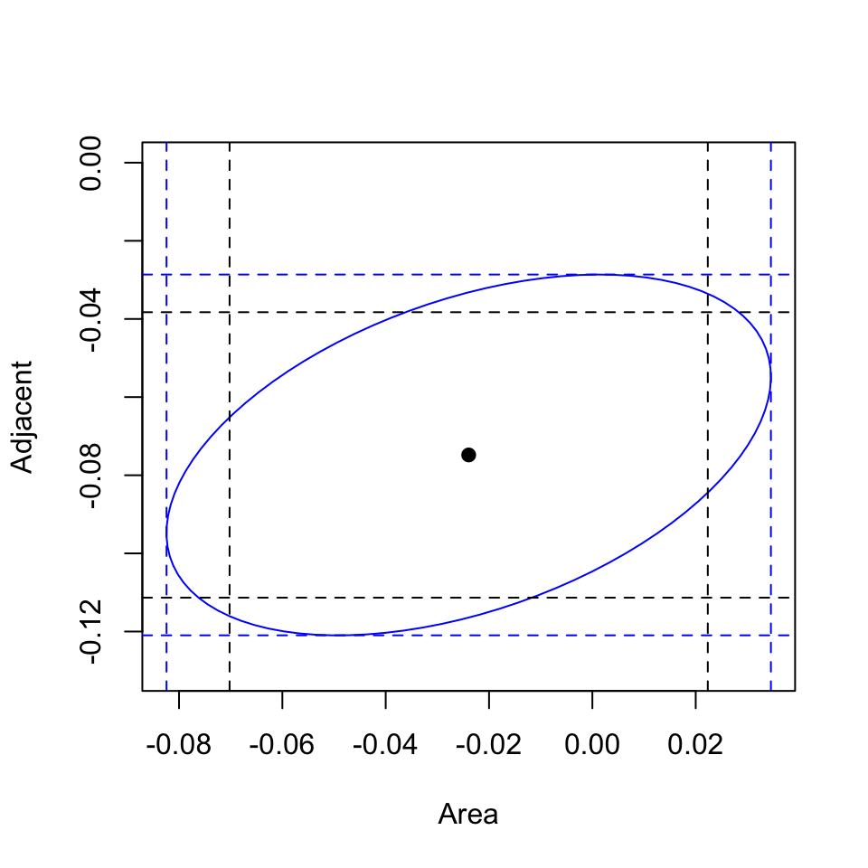

## Teste de Hipótese Linear

## Teste de Hipótese Linear

Teste de hipótese linear:

\(H_0\): \(\mathbf{R}_{r\times p}\boldsymbol{\beta}_{p\times 1}=\mathbf{q}_{r\times1}\)

\(H_1\): \(\mathbf{R}_{r\times p}\boldsymbol{\beta}_{p\times 1}\neq\mathbf{q}_{r\times1}\)

Para testar, começamos pensando no vetor de discrepância com relação à \(H_0\):

\[\mathbf{R}_{r\times p}\hat{\boldsymbol{\beta}}_{p\times 1}-\mathbf{q}_{r\times1}=\mathbf{m}_{r\times 1}\]

queremos medir quão longe \(\mathbf{m}\) está de \(\mathbf{0}\).

## Teste de Wald para Hipótese Linear

Precisamos então conhecer a distribuição de \(\mathbf{m}\), sob \(H_0\):

\[E(\mathbf{m})=E(\mathbf{R}\hat{\boldsymbol{\beta}}-\mathbf{q}) = \mathbf{R}E(\hat{\boldsymbol{\beta}})-\mathbf{q}=\mathbf{R}\boldsymbol{\beta}-\mathbf{q}\overset{H_0}{=}\mathbf{0}\]

\[Var(\mathbf{m})=Var(\mathbf{R}\hat{\boldsymbol{\beta}}-\mathbf{q}) = \mathbf{R}Var(\hat{\boldsymbol{\beta}})\mathbf{R}^T=\sigma^2\mathbf{R}(\mathbf{X}^T\mathbf{X})^{-1}\mathbf{R}^T\]

Estatística do teste:

\[\begin{eqnarray} W&=&\mathbf{m}^T[Var(\mathbf{m})]^{-1}\mathbf{m}\\ &=& (\mathbf{R}\hat{\boldsymbol{\beta}}-\mathbf{q})^T [\sigma^2\mathbf{R}(\mathbf{X}^T\mathbf{X})^{-1}\mathbf{R}^T]^{-1} (\mathbf{R}\hat{\boldsymbol{\beta}}-\mathbf{q})\\ &\overset{H_0}{\sim} & \chi^2(r) \end{eqnarray}\]

## Teste de Wald para Hipótese Linear

Problema: não conhecemos \(\sigma^2\). Temos que utilizar um estimador para \(\sigma^2\): \(s^2\).

Sabemos que \((n-p)\frac{s^2}{\sigma^2}\sim\chi^2(n-p)\).

A estatística do teste é:

\[\begin{eqnarray} F&=&\frac{W}{r}\frac{\sigma^2}{s^2}\\ &=&\frac{(\mathbf{R}\hat{\boldsymbol{\beta}}-\mathbf{q})^T [\mathbf{R}(\mathbf{X}^T\mathbf{X})^{-1}\mathbf{R}^T]^{-1} (\mathbf{R}\hat{\boldsymbol{\beta}}-\mathbf{q})}{r\sigma^2}\frac{\sigma^2}{s^2}\\ &=&\frac{(\mathbf{R}\hat{\boldsymbol{\beta}}-\mathbf{q})^T [s^2\mathbf{R}(\mathbf{X}^T\mathbf{X})^{-1}\mathbf{R}^T]^{-1} (\mathbf{R}\hat{\boldsymbol{\beta}}-\mathbf{q})}{r}\\ &\overset{H_0}{\sim} & F_{r,n-p} \end{eqnarray}\]

## Exemplo

- Para \(H_0\): \(\beta_j=0\), definimos

\(\mathbf{R}=[0\quad 0\quad\ldots\quad 1\quad 0\quad\ldots\quad 0]\) e \(\mathbf{q}=0\).

- Para \(H_0\): \(\beta_k=\beta_j\), definimos

\(\mathbf{R}=[0\quad 0\quad 1\quad \ldots\quad -1\quad 0\quad\ldots\quad 0]\) e \(\mathbf{q}=0\).

- Para \(H_0\): \(\beta_1+\beta_2+\beta_3=1\), definimos

\(\mathbf{R}=[0\quad 1\quad 1\quad 1 \quad 0\quad\ldots\quad 0]\) e \(\mathbf{q}=1\).

## Exemplo

- Para \(H_0\): \(\beta_0=0\), \(\beta_1=0\) e \(\beta_2=0\), definimos

\[\mathbf{R}=\left( \begin{array}{cccccc} 1 & 0 & 0 & 0 & \ldots & 0\\ 0 & 1 & 0 & 0 & \ldots & 0\\ 0 & 0 & 1 & 0 & \ldots & 0\\ \end{array} \right) \quad\quad\mathbf{q}=\mathbf{0} \]

- Para \(H_0\): \(\beta_1+\beta_2=1\), \(\beta_3+\beta_5=0\) e \(\beta_4+\beta_5=0\), definimos

\[\mathbf{R}=\left( \begin{array}{cccccc} 0 & 1 & 1 & 0 & 0 & 0\\ 0 & 0 & 0 & 1 & 0 & 1\\ 0 & 0 & 0 & 0 & 1 & 1\\ \end{array} \right) \quad\quad\mathbf{q}=\left( \begin{array}{c} 1\\ 0\\ 0 \end{array} \right) \]

## Exemplo

```r
library(systemfit)
data( "Kmenta" )
modelo <- lm(consump ~ price + income,data=Kmenta)
summary(modelo)$coef
```

```
##               Estimate Std. Error   t value     Pr(>|t|)
## (Intercept) 99.8954229 7.51936214 13.285093 2.090605e-10
## price       -0.3162988 0.09067741 -3.488177 2.815290e-03
## income       0.3346356 0.04542183  7.367285 1.099860e-06
```

\[Y=\beta_0+\beta_1X_1+\beta_2X_2+\varepsilon\]

\(X_1\): price

\(X_2\): income

## Exemplo

\(H_0\): \(\beta_1=0\)

```r
R <- matrix( c(0,1,0),ncol=length(coef(modelo)),byrow=TRUE)
linearHypothesis(modelo,R)
```

```
## Linear hypothesis test
##
## Hypothesis:
## price = 0
##
## Model 1: restricted model
## Model 2: consump ~ price + income
##
##   Res.Df     RSS Df Sum of Sq      F   Pr(>F)
## 1     18 108.660
## 2     17  63.332  1    45.328 12.167 0.002815 **
## ---
## Signif. codes:  0 '***' 0.001 '**' 0.01 '*' 0.05 '.' 0.1 ' ' 1
```

## Exemplo

\(H_0\): \(\beta_1=2\)

```r
R <- matrix( c(0,1,0),ncol=length(coef(modelo)),byrow=TRUE)
q=2
linearHypothesis(modelo,R,q)
```

```
## Linear hypothesis test
##
## Hypothesis:
## price = 2
##
## Model 1: restricted model
## Model 2: consump ~ price + income
##
##   Res.Df     RSS Df Sum of Sq      F    Pr(>F)
## 1     18 2494.21
## 2     17   63.33  1    2430.9 652.52 5.311e-15 ***
## ---
## Signif. codes:  0 '***' 0.001 '**' 0.01 '*' 0.05 '.' 0.1 ' ' 1
```

## Exemplo

\(H_0\): \(\beta_1=2\) e \(\beta_2=1\).

```r
R <- matrix( c(0,1,0,
               0,0,1),ncol=length(coef(modelo)),byrow=TRUE)
q=matrix(c(2,1),ncol=1)
linearHypothesis(modelo,R,q)
```

```
## Linear hypothesis test
##
## Hypothesis:
## price = 2
## income = 1
##
## Model 1: restricted model
## Model 2: consump ~ price + income
##
##   Res.Df    RSS Df Sum of Sq     F    Pr(>F)
## 1     19 7146.8
## 2     17   63.3  2    7083.4 950.7 < 2.2e-16 ***
## ---
## Signif. codes:  0 '***' 0.001 '**' 0.01 '*' 0.05 '.' 0.1 ' ' 1
```

## Leituras

- [The Matrix Cookbook](https://www.math.uwaterloo.ca/~hwolkowi/matrixcookbook.pdf)
- Faraway - [Linear Models with R](http://www.maths.bath.ac.uk/~jjf23/LMR/): Seção 3.5.
- Draper & Smith - [Applied Regression Analysis](http://onlinelibrary.wiley.com/book/10.1002/9781118625590): Seção 9.1.